# Filtering TCR data

Wei Sun

2023-09-25

## Load R libraries

```r
library(data.table)
library(Matrix)
library(ggplot2)
library(ggpubr)
library(stringr)
library(readxl)
library(Biostrings)
library(stringr)
library(ggrepel)
theme_set(theme_classic())
```

## Hanada_2022

Hanada, K. I., Zhao, C., Gil-Hoyos, R., Gartner, J. J., Chow-Parmer, C., Lowery, F. J., … & Yang, J. C. (2022). A phenotypic signature that identifies neoantigen-reactive T cells in fresh human lung cancers. Cancer Cell, 40(5), 479-493.

```r
hanada = read_excel("data/Hanada_2022_Table_S3.xlsx", range = "A4:L17")
hanada = as.data.frame(hanada)
names(hanada)[1:3] = c("cloneType_ID", "antigen_identified", "antigen")

hanada$patient = "Patient1"
hanada$cell_type = "CD8"

dim(hanada)
```

```
## [1] 13 14
```

```r
hanada[1:2,]
```

```
##     cloneType_ID antigen_identified antigen Wildtype Mutated    TRAV   TRAJ
## 1 CD8_CD39(-) #1                 No    <NA>     <NA>    <NA>  TRAV17 ARAJ13
## 2 CD8_CD39(-) #2                 No    <NA>     <NA>    <NA> TRAV8-4 TRAJ23
##              CDR3    TRBV  TRBD    TRBJ           CDR3B  patient cell_type
## 1 CATDAGSGGYQKVTF TRBV6-2 TRBD2 TRBJ1-5 CASSLYRDSNQPQHF Patient1       CD8
## 2    CAVTGGGGKLIF TRBV4-1  <NA> TRBJ2-5   CASNAPGQETQYF Patient1       CD8
```

```r
read_segment <- function(range1, patient, cell_type){
  dat = read_excel("data/Hanada_2022_Table_S3.xlsx", range = range1)
  dat = as.data.frame(dat)
  names(dat)[1:3] = c("cloneType_ID", "antigen_identified", "antigen")

  dat$patient = patient
  dat$cell_type = cell_type
  dat
}

hanada = rbind(hanada, read_segment("A21:L33", "Patient1", "CD4"))
hanada = rbind(hanada, read_segment("A37:L57", "Patient2", "CD8"))
hanada = rbind(hanada, read_segment("A61:L76", "Patient2", "CD4"))
hanada = rbind(hanada, read_segment("A80:L97", "Patient3", "CD8"))
hanada = rbind(hanada, read_segment("A101:L117", "Patient3", "CD4"))
hanada = rbind(hanada, read_segment("A121:L132", "Patient4", "CD8"))
hanada = rbind(hanada, read_segment("A136:L140", "Patient4", "CD4"))
dim(hanada)
```

```
## [1] 108  14
```

```r
hanada[1:2,]
```

```
##     cloneType_ID antigen_identified antigen Wildtype Mutated    TRAV   TRAJ
## 1 CD8_CD39(-) #1                 No    <NA>     <NA>    <NA>  TRAV17 ARAJ13
## 2 CD8_CD39(-) #2                 No    <NA>     <NA>    <NA> TRAV8-4 TRAJ23
##              CDR3    TRBV  TRBD    TRBJ           CDR3B  patient cell_type
## 1 CATDAGSGGYQKVTF TRBV6-2 TRBD2 TRBJ1-5 CASSLYRDSNQPQHF Patient1       CD8
## 2    CAVTGGGGKLIF TRBV4-1  <NA> TRBJ2-5   CASNAPGQETQYF Patient1       CD8
```

```r
hanada = hanada[,-1]
table(hanada$antigen_identified)
```

```
##
##  No Yes
##  63  45
```

```r
hanada = hanada[hanada$antigen_identified == "Yes",]
hanada$antigen_type = "neoantigen"

hanada = hanada[,c("TRAV", "TRAJ", "CDR3", "TRBV", "TRBD", "TRBJ",
                   "CDR3B", "antigen", "antigen_type", "Mutated",
                   "patient", "cell_type")]

names(hanada)[c(3,10)] = c("CDR3A", "epitope")
hanada$study = "Hanada_2022"
hanada$cancer_type = "NSCLC"
dim(hanada)
```

```
## [1] 45 14
```

```r
hanada[1:2,]
```

```
##      TRAV   TRAJ          CDR3A    TRBV  TRBD    TRBJ           CDR3B antigen
## 8 TRAV8-1 TRAJ39 CAVNVNNAGNMLTF TRBV7-6 TRBD2 TRBJ2-3 CASSALSGSINTQYF   BPNT1
## 9 TRAV8-6 TRAJ39 CAVSEKNAGNMLTF TRBV7-6 TRBD2 TRBJ2-1 CASSPNSGSQNEQFF   BPNT1
##   antigen_type    epitope  patient cell_type       study cancer_type
## 8   neoantigen EAGPDAVLRR Patient1       CD8 Hanada_2022       NSCLC
## 9   neoantigen EAGPDAVLRR Patient1       CD8 Hanada_2022       NSCLC
```

```r
table(hanada$patient, hanada$cell_type)
```

```
##
##            CD4 CD8
##   Patient1   7   5
##   Patient2   6  11
##   Patient3  10   3
##   Patient4   0   3
```

```r
table(table(hanada$CDR3B))
```

```
##
##  1
## 45
```

```r
table(hanada$antigen_type)
```

```
##
## neoantigen
##         45
```

## Lowery_2022

Lowery, F. J., Krishna, S., … & Rosenberg, S. A. (2022). Molecular signatures of antitumor neoantigen-reactive T cells from metastatic human cancers. Science, 375(6583), 877-884.

```r
lowery1 = read_excel("data/Lowery_Table_S7.xlsx", sheet=1,
                     range="A1:J55")
lowery1 = data.frame(lowery1)
dim(lowery1)
```

```
## [1] 54 10
```

```r
lowery1[1:2,]
```

```
##   CD4.CD8        CDR3A             CDR3B Archival.Prospective Tumor.ID
## 1     CD8 CASYTNAGKSTF CASSQERGLAGFNEQFF             Archival     4261
## 2     CD8 CAYRIGNTPLVF   CASRGGLTGTEKLFF             Archival     4261
##   Clonotype Previously.known.or.newly.identified
## 1    4261-1                                Known
## 2    4261-2                                Known
##   Mutated.gene.or.tumor.reactivity Mutation Cluster
## 1                             ATL2   p.G84D     C11
## 2                             ATL2   p.G84D      C6
```

```r
lowery2 = read_excel("data/Lowery_Table_S7.xlsx", sheet=2)
lowery2 = data.frame(lowery2)
dim(lowery2)
```

```
## [1] 37 11
```

```r
lowery2[1:2,]
```

```
##   CD4.CD8             CDR3A          CDR3B Archival.Prospective Tumor.ID
## 1     CD4    CALSGSSNTGKLIF   CSALQVPSGYTF          Prospective     4393
## 2     CD4 CAFMKLGSNFGNEKLTF CASSRTGANYGYTF          Prospective     4393
##    Clonotype Previously.known.or.newly.identified Antigen.reactivity
## 1 4393 CD4 A                     Newly identified               FUT1
## 2 4393 CD4 B                     Newly identified               PCNT
##       Mutation Tumor.reactivity Clone.count
## 1 p.343_344del             none           4
## 2     p.P2122L             none           3
```

```r
lowery3 = read_excel("data/Lowery_Table_S7.xlsx", sheet=3)
lowery3 = data.frame(lowery3)
dim(lowery3)
```

```
## [1] 15 10
```

```r
lowery3[1:2,]
```

```
##   CD4.CD8           CDR3A         CDR3B Archival.Prospective Tumor.ID Clonotype
## 1     CD8 CAVGVGGTSYGKLTF CASSLRGSYEQYV             Archival     4283    4283-1
## 2     CD8 CAESKGGGGADGLTF  CASSPGGFEAFF             Archival     4317    4317-1
##   Previously.known.or.newly.identified Antigen.reactivity Mutation
## 1                                Known             DNMT3A  p.P282S
## 2                                Known             PIK3CA  p.P449T
##   HLA.Restriction
## 1         B*44:03
## 2         A*02:01
```

```r
names(lowery1)[8] = names(lowery2)[8] = names(lowery3)[8] = "antigen"
lowery = rbind(lowery1[,1:9], lowery2[,1:9])

lowery$CDR3  = paste(lowery$CDR3A, lowery$CDR3B, sep=":")
lowery3$CDR3 = paste(lowery3$CDR3A, lowery3$CDR3B, sep=":")

table(lowery3$CDR3 %in% lowery$CDR3)
```

```
##
## FALSE  TRUE
##     1    14
```

```r
tb1 = table(lowery$CDR3B)
table(tb1)
```

```
## tb1
##  1  2
## 89  1
```

```r
lowery = lowery[order(lowery$CDR3B),]
lowery[lowery$CDR3B %in% names(tb1)[tb1>1],]
```

```
##    CD4.CD8           CDR3A            CDR3B Archival.Prospective Tumor.ID
## 27     CD4  CAVSPTGSARQLTF CASRGAPGRENTEAFF             Archival     4342
## 28     CD4 CAMREGGYNFNKFYF CASRGAPGRENTEAFF             Archival     4342
##    Clonotype Previously.known.or.newly.identified antigen Mutation
## 27    4342-4                                Known     FN1  p.R290C
## 28    4342-5                                Known     FN1  p.R290C
##                                CDR3
## 27  CAVSPTGSARQLTF:CASRGAPGRENTEAFF
## 28 CAMREGGYNFNKFYF:CASRGAPGRENTEAFF
```

```r
names(lowery)[1] = "cell_type"
names(lowery)[5] = "patient"
names(lowery)[9] = "epitope"
dim(lowery)
```

```
## [1] 91 10
```

```r
lowery[1:2,]
```

```
##    cell_type              CDR3A         CDR3B Archival.Prospective patient
## 87       CD8    CAVSPGRDSSYKLIF  CAADRGDYGYTF          Prospective    4421
## 42       CD4 CALSDPGGSGGGADGLTF CALRRSASYEQYV             Archival    4283
##     Clonotype Previously.known.or.newly.identified antigen  epitope
## 87 4421 CD8 N                     Newly identified    FLNB p.H2539Q
## 42     4283-8                     Newly identified   SP100  p.P390S
##                                CDR3
## 87     CAVSPGRDSSYKLIF:CAADRGDYGYTF
## 42 CALSDPGGSGGGADGLTF:CALRRSASYEQYV
```

```r
l1 = lowery
lowery = data.frame(TRAV=NA, TRAJ=NA, CDR3A=l1$CDR3A,
                    TRBV=NA, TRBD=NA, TRBJ=NA, CDR3B=l1$CDR3B,
                    antigen=l1$antigen, antigen_type="neoantigen",
                    epitope=l1$epitope, patient=l1$patient,
                    cell_type=l1$cell_type, study="Lowery_2022",
                    cancer_type="")

patient_info = read_excel("data/Lowery_Table_S1.xlsx")
patient_info = as.data.frame(patient_info)
dim(patient_info)
```

```
## [1] 15  8
```

```r
patient_info[1:2,]
```

```
##   Patient Tumor Age Sex Histology Site of TIL Harvest Prior Immune Checkpoints
## 1          4261  57   M  Melanoma          Lymph Node            Pembrolizumab
## 2          4283  54   F     Colon                Lung                        N
##                                            HLA class I
## 1 A*03:01, A*11:01, B*35:03, B*55:01, C*03:03, C*04:01
## 2 A*01:01, A*11:01, B*44:03, B*56:01, C*04:01, C*01:02
##                                                                                                                                                                               HLA class II
## 1 DPA1*01:03-DPB1*03:01, DPA1*01:03-DPB1*04:01, DQA1*03:01-DQB1*03:01, DQA1*03:01-DQB1*03:02, DQA1*05:05-DQB1*03:01, DQA1*05:05-DQB1*03:02, DRB1*04:04, DRB1*12:01, DRB3*02:02, DRB4*01:01
## 2                                           DPA1*01:03, DPB1*04:02, DPB1*03:01, DQA1*01:01, DQA1*02:01, DQB1*05:01, DQB1*02:02, DRB1*01:01:01, DRB1*07:01:01, DRB3*01:01:02, DRB4*01:01:01
```

```r
table(lowery$patient, useNA = "ifany")
```

```
##
## 4261 4283 4298 4317 4322 4323 4324 4342 4385 4393 4394 4400 4421
##    2   10   11    3    5   11    4    7    1   11    3   14    9
```

```r
mat1 = match(lowery$patient, patient_info$`Patient Tumor`)
stopifnot(all(!is.na(mat1)))

lowery$cancer_type = patient_info$Histology[mat1]

dim(lowery)
```

```
## [1] 91 14
```

```r
lowery[1:2,]
```

```
##   TRAV TRAJ              CDR3A TRBV TRBD TRBJ         CDR3B antigen
## 1   NA   NA    CAVSPGRDSSYKLIF   NA   NA   NA  CAADRGDYGYTF    FLNB
## 2   NA   NA CALSDPGGSGGGADGLTF   NA   NA   NA CALRRSASYEQYV   SP100
##   antigen_type  epitope patient cell_type       study cancer_type
## 1   neoantigen p.H2539Q    4421       CD8 Lowery_2022       Colon
## 2   neoantigen  p.P390S    4283       CD4 Lowery_2022       Colon
```

```r
table(lowery$antigen_type)
```

```
##
## neoantigen
##         91
```

## Caushi_2021

Caushi, J. X., Zhang, J., Ji, Z., Vaghasia, A., Zhang, B., Hsiue, E. H. C., … & Smith, K. N. (2021). Transcriptional programs of neoantigen-specific TIL in anti-PD-1-treated lung cancers. Nature, 596(7870), 126-132.

```r
caushi = fread("data/Caushi_2021_Table_S8.csv")
dim(caushi)
```

```
## [1] 159  22
```

```r
caushi[1:2,]
```

```
##      Patient TCR clonotype (AA) Type of antigen recognized (viral or MANA)
## 1:  MD01-004     CASSLPGTPYEQYF                                       MANA
## 2: MD043-011      CASSRGDPYEQYF                                       MANA
##    Epitope recognized in MANA/ViraFEST assay Antigen recognized (protein)
## 1:                               NSSCMGGMNLR                         TP53
## 2:                               FAAQAGAWKIY                        CARM1
##    Antigen specificity matched to VDJdb Lymph node Metastatic tumor
## 1:                                 <NA>         45               NA
## 2:                                 <NA>         37                0
##    Adjacent normal lung Tumor Peripheral blood Flu peptide (IL-7 Expt.)
## 1:                   NA    16               NA                       55
## 2:                    0     5               NA                       NA
##    MANA peptide (IL-7 Expt.) V14 V15 V16 V17 V18 V19 V20 V21 V22
## 1:                        32  NA  NA  NA  NA  NA  NA  NA  NA  NA
## 2:                        NA  NA  NA  NA  NA  NA  NA  NA  NA  NA
```

```r
names(caushi)[1:5] = c("patient", "TCRB", "antigen_type", "epitope",
                       "antigen")
caushi = caushi[,1:5]
dim(caushi)
```

```
## [1] 159   5
```

```r
caushi[1:2,]
```

```
##      patient           TCRB antigen_type     epitope antigen
## 1:  MD01-004 CASSLPGTPYEQYF         MANA NSSCMGGMNLR    TP53
## 2: MD043-011  CASSRGDPYEQYF         MANA FAAQAGAWKIY   CARM1
```

```r
caushi[antigen_type == "MANA", antigen_type:= "neoantigen"]
caushi[antigen_type == "Viral (CMV, EBV, Influenza A)",
       antigen_type:= "viral_CEF"]
caushi[antigen_type == "Viral (Influenza)",
       antigen_type:= "viral_Influenza"]

caushi$antigen[which(caushi$antigen == "unknown")] = NA

l1 = caushi
caushi = data.frame(TRAV=NA, TRAJ=NA, CDR3A=NA,
                    TRBV=NA, TRBD=NA, TRBJ=NA, CDR3B=l1$TCRB,
                    antigen=l1$antigen, antigen_type=l1$antigen_type,
                    epitope=l1$epitope, patient=l1$patient,
                    cell_type=NA, study="Caushi_2021",
                    cancer_type="NSCLC")

dim(caushi)
```

```
## [1] 159  14
```

```r
caushi[1:2,]
```

```
##   TRAV TRAJ CDR3A TRBV TRBD TRBJ          CDR3B antigen antigen_type
## 1   NA   NA    NA   NA   NA   NA CASSLPGTPYEQYF    TP53   neoantigen
## 2   NA   NA    NA   NA   NA   NA  CASSRGDPYEQYF   CARM1   neoantigen
##       epitope   patient cell_type       study cancer_type
## 1 NSSCMGGMNLR  MD01-004        NA Caushi_2021       NSCLC
## 2 FAAQAGAWKIY MD043-011        NA Caushi_2021       NSCLC
```

```r
table(caushi$patient, caushi$antigen_type)
```

```
##
##             neoantigen viral_CEF viral_Influenza
##   MD01-004          42         2              21
##   MD01-005           4         6              21
##   MD043-003          2        12               0
##   MD043-008          0        13               0
##   MD043-011          4         0              10
##   NY016-007          2         0               0
##   NY016-014         16         0               0
##   NY016-025          4         0               0
```

## Sudmeier_2022

Sudmeier, L. J., Hoang, K. B., Nduom, E. K., Wieland, A., Neill, S. G., Schniederjan, M. J., … & Hudson, W. H. (2022). Distinct phenotypic states and spatial distribution of CD8+ T cell clonotypes in human brain metastases. Cell Reports Medicine, 3(5), 100620.

All the TCRs reported by Sudmeier et al. are not cancer reactive, but are CEFX (a microbe pool) reactive.

```r
sudmeier = fread("data/Sudmeier_2022_cefx_cells.txt",
                 blank.lines.skip = TRUE, header = TRUE)
dim(sudmeier)
```

```
## [1] 175   3
```

```r
sudmeier[1:3,]
```

```
##                         V1                    clonotype patient
## 1: pt05_AAACGGGGTCGAGATG-1  TRBV2_TRBJ1_CASSGDRQMNTEAFF    pt05
## 2: pt05_AAGGCAGAGACATAAC-1 TRBV20_TRBJ1_CSARDTGQATYGYTF    pt05
## 3: pt05_ACACCAACATGGTCTA-1  TRBV2_TRBJ1_CASSGDRQMNTEAFF    pt05
```

```r
tcr_info = str_split(sudmeier$clonotype, pattern="_", simplify = TRUE)
dim(tcr_info)
```

```
## [1] 175   3
```

```r
tcr_info[1:2,]
```

```
##      [,1]     [,2]    [,3]
## [1,] "TRBV2"  "TRBJ1" "CASSGDRQMNTEAFF"
## [2,] "TRBV20" "TRBJ1" "CSARDTGQATYGYTF"
```

```r
sudmeier[,v_gene := tcr_info[,1]]
sudmeier[,j_gene := tcr_info[,2]]
sudmeier[,cdr3 := tcr_info[,3]]

dim(sudmeier)
```

```
## [1] 175   6
```

```r
sudmeier[1:3,]
```

```
##                         V1                    clonotype patient v_gene j_gene
## 1: pt05_AAACGGGGTCGAGATG-1  TRBV2_TRBJ1_CASSGDRQMNTEAFF    pt05  TRBV2  TRBJ1
## 2: pt05_AAGGCAGAGACATAAC-1 TRBV20_TRBJ1_CSARDTGQATYGYTF    pt05 TRBV20  TRBJ1
## 3: pt05_ACACCAACATGGTCTA-1  TRBV2_TRBJ1_CASSGDRQMNTEAFF    pt05  TRBV2  TRBJ1
##               cdr3
## 1: CASSGDRQMNTEAFF
## 2: CSARDTGQATYGYTF
## 3: CASSGDRQMNTEAFF
```

```r
l1 = sudmeier
sudmeier = data.frame(TRAV=NA, TRAJ=NA, CDR3A=NA,
                    TRBV=l1$v_gene, TRBD=NA, TRBJ=l1$j_gene, CDR3B=l1$cdr3,
                    antigen=NA, antigen_type="viral",
                    epitope="", patient=l1$patient,
                    cell_type=NA, study="Sudmeier_2022",
                    cancer_type="Brain_metastases")

dim(sudmeier)
```

```
## [1] 175  14
```

```r
sudmeier[1:2,]
```

```
##   TRAV TRAJ CDR3A   TRBV TRBD  TRBJ           CDR3B antigen antigen_type
## 1   NA   NA    NA  TRBV2   NA TRBJ1 CASSGDRQMNTEAFF      NA        viral
## 2   NA   NA    NA TRBV20   NA TRBJ1 CSARDTGQATYGYTF      NA        viral
##   epitope patient cell_type         study      cancer_type
## 1            pt05        NA Sudmeier_2022 Brain_metastases
## 2            pt05        NA Sudmeier_2022 Brain_metastases
```

```r
table(sudmeier$patient)
```

```
##
## pt05 pt15 pt16 pt17
##   43    2  119   11
```

```r
table(sudmeier$patient, sudmeier$antigen_type)
```

```
##
##        viral
##   pt05    43
##   pt15     2
##   pt16   119
##   pt17    11
```

## Veatch_2022

Veatch, J. R., Lee, S. M., … & Riddell, S. R. (2022). Neoantigen-specific CD4+ T cells in human melanoma have diverse differentiation states and correlate with CD8+ T cell, macrophage, and B cell function. Cancer cell, 40(4), 393-409.

### A function to extract CDR3 from DNA sequence.

```r
table(str_sub(hanada$CDR3B, 1, 2))
```

```
##
## AS CA CS
##  4 39  2
```

```r
table(str_sub(hanada$CDR3B, -1, -1))
```

```
##
##  F
## 45
```

```r
table(str_sub(lowery$CDR3B, 1, 2))
```

```
##
## CA CS
## 81 10
```

```r
table(str_sub(lowery$CDR3B, -1, -1))
```

```
##
##  F  V
## 89  2
```

```r
table(str_sub(sudmeier$CDR3B, 1, 2))
```

```
##
##  CA  CS
## 150  25
```

```r
table(str_sub(sudmeier$CDR3B, -1, -1))
```

```
##
##   F
## 175
```

```r
DNA2CDR3 <- function(x){

  cdr3_all = rep("", length(x))

  # remove those with "N" in the DNA sequence
  gN = grep("N", x)
  length(gN)

  if(length(gN) > 0){
    cdr3_all[gN] = NA
    x = x[-gN]
  }
  table(is.na(cdr3_all))

  aa = as.character(translate(DNAStringSet(x)))

  CDR3 = str_sub(aa, start = 1L, end=-3L)

  start_pos = str_locate(CDR3, "CA|CS")
  w2rm = which(is.na(start_pos[,1]))
  start_pos[w2rm,1] = 1
  CDR3 = str_sub(CDR3, start = start_pos[,1], end=-1L)
  CDR3[w2rm] = NA

  if(length(gN) > 0){
    cdr3_all[-gN] = CDR3
  }else{
    cdr3_all = CDR3
  }

  print("first two AA:")
  print(table(str_sub(cdr3_all, 1, 2), useNA="ifany"))
  print("last AA:")
  print(table(str_sub(cdr3_all, -1, -1), useNA="ifany"))
  print("CDR3 length:")
  print(table(nchar(cdr3_all), useNA="ifany"))

  cdr3_all
}
```

### Collect TCR data

The number of TCRs responding to neoantigen, self-antigen, and viral antigen can be found in Figure 1I of Veatch et al.

```r
patients = c("X422", "X197", "X205", "X198")

veatch = NULL

for(p1 in patients){
  if(p1 == "X205"){
    dat = read_excel("data/x205 adaptive 8-17-20.xlsx")
    dat = data.frame(dat)
  }else{
    dat = read_excel("data/Veatch_2022_Table_S2.xlsx", skip = 2,
                   sheet=p1)
    dat = data.frame(dat)
  }
  dim(dat)
  dat[1:3,1:min(15,ncol(dat))]

  names(dat)[1] = "Rearrangement"
  table(nchar(dat$Rearrangement))

  if(p1 == "X197" || p1 == "X198"){
    dat$Rearrangement = str_sub(dat$Rearrangement, start=3)
  }

  dat$CDR3 = DNA2CDR3(dat$Rearrangement)

  if(p1 == "X422"){
    w2kp = which(dat$antigen != "")
    df1  = dat[w2kp, c("CDR3", "antigen")]
    df1$antigen_type = "neoantigen"
    df1$patient = p1
    df1 = unique(df1)
    veatch = rbind(veatch, df1)
  }

  if(p1 == "X197"){
    w2kp = which(dat$clone == "BRAF")
    df1 = data.frame(CDR3=dat$CDR3[w2kp], antigen="BRAF")
    df1$antigen_type = "neoantigen"
    df1$patient = p1
    df1 = unique(df1)
    veatch = rbind(veatch, df1)

    w2kp = which(dat$viral == "viral")
    df1 = data.frame(CDR3=dat$CDR3[w2kp], antigen=NA)
    df1$antigen_type = "viral"
    df1$patient = p1
    df1 = unique(df1)
    veatch = rbind(veatch, df1)
  }

  if(p1 == "X205"){
    w_neoag = which(!is.na(dat$clone.neo))
    w_self  = which(dat$self == "self")
    w_viral = which(dat$viral.pd.1.int == "viral" | dat$viral.pd.1.low == "viral")

    df1  = dat[w_neoag, c("CDR3", "clone.neo")]
    names(df1)[2] = "antigen"
    df1$antigen[df1$antigen == "unknown"] = NA

    df1$antigen_type = "neoantigen"
    df1$patient = p1
    df1 = unique(df1)

    veatch = rbind(veatch, df1)

    df1  = dat[w_self, c("CDR3", "self")]
    names(df1)[2] = "antigen"
    df1$antigen_type = "self"
    df1$patient = p1
    df1$antigen = NA
    df1 = unique(df1)

    veatch = rbind(veatch, df1)

    df1  = dat[w_viral, c("CDR3", "viral.pd.1.int")]
    names(df1)[2] = "antigen"
    df1$antigen = NA
    df1$antigen_type = "viral"
    df1$patient = p1
    df1 = unique(df1)

    veatch = rbind(veatch, df1)
  }

  if(p1 == "X198"){
    w2kp = which((!is.na(dat$CD4.clone...2)))
    df1  = dat[w2kp, c("CDR3", "CD4.clone...2")]
    names(df1)[2] = "antigen"
    df1$antigen_type = "neoantigen"
    df1$antigen_type[which(df1$antigen == "Viral")] = "viral"
    df1$antigen[which(df1$antigen == "Viral")] = NA
    df1$patient = p1
    df1 = unique(df1)

    veatch = rbind(veatch, df1)
  }
}
```

```
## [1] "first two AA:"
##
##   CA   CS <NA>
## 2844  344  309
## [1] "last AA:"
##
##    F    I    L <NA>
## 3182    1    5  309
## [1] "CDR3 length:"
##
##    9   10   11   12   13   14   15   16   17   18   19   20   21   23   25 <NA>
##    1   11   75  219  497  697  720  488  281  127   48   14    7    2    1  309
## [1] "first two AA:"
##
##   CA   CS <NA>
## 2474  227   21
## [1] "last AA:"
##
##    F <NA>
## 2701   21
## [1] "CDR3 length:"
##
##    5    8    9   10   11   12   13   14   15   16   17   18   19 <NA>
##    1    2    1   17  130  248  485  642  610  332  145   60   28   21
## [1] "first two AA:"
##
##   CA   CS <NA>
## 5435  579   68
## [1] "last AA:"
##
##    C    F    G    I    L    S    T    V    Y <NA>
##    4 5970    3    1   18    4    1   11    2   68
## [1] "CDR3 length:"
##
##    5    9   10   11   12   13   14   15   16   17   18   19   20   21   22   23
##    1    3   26  175  486  963 1401 1381  857  384  205   81   21   12    3    7
##   24   25   26   27 <NA>
##    3    2    2    1   68
```

```
## [1] "first two AA:"
##
##   CA   CS <NA>
## 3277  395   29
## [1] "last AA:"
##
##    F    L    T <NA>
## 3670    1    1   29
## [1] "CDR3 length:"
##
##    7    8    9   10   11   12   13   14   15   16   17   18   19 <NA>
##    3    2    5   22  128  342  744  866  812  419  202   88   39   29
```

```r
dim(veatch)
```

```
## [1] 407   4
```

```r
veatch[1:2,]
```

```
##                 CDR3 antigen antigen_type patient
## 4    CASSLGLADHYEQYF   EIF3M   neoantigen    X422
## 5 CASSLGLAGVTGANVLTF ABHD17B   neoantigen    X422
```

```r
l1 = veatch
veatch = data.frame(TRAV=NA, TRAJ=NA, CDR3A=NA,
                    TRBV=NA, TRBD=NA, TRBJ=NA, CDR3B=l1$CDR3,
                    antigen=l1$antigen, antigen_type=l1$antigen_type,
                    epitope="", patient=l1$patient,
                    cell_type="CD4", study="Veatch_2022",
                    cancer_type="Melanoma")

dim(veatch)
```

```
## [1] 407  14
```

```r
veatch[1:2,]
```

```
##   TRAV TRAJ CDR3A TRBV TRBD TRBJ              CDR3B antigen antigen_type
## 1   NA   NA    NA   NA   NA   NA    CASSLGLADHYEQYF   EIF3M   neoantigen
## 2   NA   NA    NA   NA   NA   NA CASSLGLAGVTGANVLTF ABHD17B   neoantigen
##   epitope patient cell_type       study cancer_type
## 1            X422       CD4 Veatch_2022    Melanoma
## 2            X422       CD4 Veatch_2022    Melanoma
```

```r
table(veatch$antigen_type, veatch$patient)
```

```
##
##              X197 X198 X205 X422
##   neoantigen    3   39   22    4
##   self          0    0   15    0
##   viral       183  117   24    0
```

## Combine data across studies

```r
df = hanada
df = rbind(df, lowery)
df = rbind(df, caushi)
df = rbind(df, sudmeier)
df = rbind(df, veatch)

dim(df)
```

```
## [1] 877  14
```

```r
df[1:2,]
```

```
##      TRAV   TRAJ          CDR3A    TRBV  TRBD    TRBJ           CDR3B antigen
## 8 TRAV8-1 TRAJ39 CAVNVNNAGNMLTF TRBV7-6 TRBD2 TRBJ2-3 CASSALSGSINTQYF   BPNT1
## 9 TRAV8-6 TRAJ39 CAVSEKNAGNMLTF TRBV7-6 TRBD2 TRBJ2-1 CASSPNSGSQNEQFF   BPNT1
##   antigen_type    epitope  patient cell_type       study cancer_type
## 8   neoantigen EAGPDAVLRR Patient1       CD8 Hanada_2022       NSCLC
## 9   neoantigen EAGPDAVLRR Patient1       CD8 Hanada_2022       NSCLC
```

```r
table(df$study, useNA="ifany")
```

```
##
##   Caushi_2021   Hanada_2022   Lowery_2022 Sudmeier_2022   Veatch_2022
##           159            45            91           175           407
```

```r
table(df$antigen_type, useNA="ifany")
```

```
##
##      neoantigen            self           viral       viral_CEF viral_Influenza
##             278              15             499              33              52
```

```r
table(df$study, df$cell_type, useNA="ifany")
```

```
##
##                 CD4 CD8 <NA>
##   Caushi_2021     0   0  159
##   Hanada_2022    23  22    0
##   Lowery_2022    44  47    0
##   Sudmeier_2022   0   0  175
##   Veatch_2022   407   0    0
```

```r
table(df$study, df$cancer_type, useNA="ifany")
```

```
##
##                 Brain_metastases Breast Colon Melanoma NSCLC Rectal
##   Caushi_2021                  0      0     0        0   159      0
##   Hanada_2022                  0      0     0        0    45      0
##   Lowery_2022                  0      5    59        2     0     25
##   Sudmeier_2022              175      0     0        0     0      0
##   Veatch_2022                  0      0     0      407     0      0
```

```r
fwrite(df, "data/cancer_reactive_TCRs.tsv", sep="\t")
```

## Compare CDR3 between cancer TCRs vs. other TCRs

### CDR3 length

```r
viral_grp = c("viral_Influenza", "viral_CEF")

df$CDR3B_len = nchar(df$CDR3B)
df$`antigen_type`[df$`antigen_type` %in% viral_grp] = "viral"

table(df$study, df$antigen_type)
```

```
##
##                 neoantigen self viral
##   Caushi_2021           74    0    85
##   Hanada_2022           45    0     0
##   Lowery_2022           91    0     0
##   Sudmeier_2022          0    0   175
##   Veatch_2022           68   15   324
```

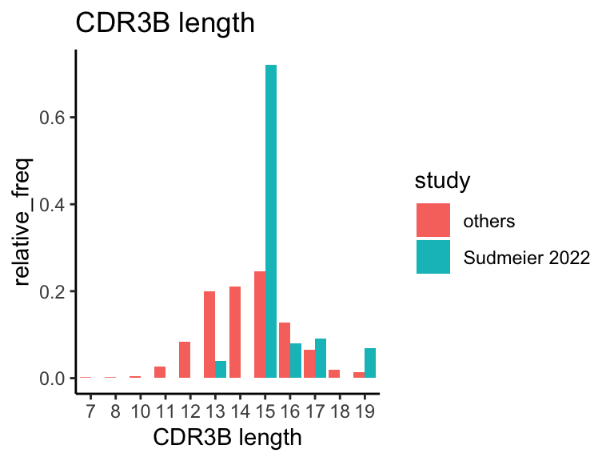

```r
df1 = as.data.frame(table(df$CDR3B_len, df$study=="Sudmeier_2022"))
names(df1) = c("CDR3B length", "Sudmeier_2022", "freq")
df1$study = "others"
df1$study[which(df1$Sudmeier_2022 == TRUE)] = "Sudmeier 2022"

df1$relative_freq = NA
for(a1 in unique(df1$study)){
  wa = which(df1$study == a1)
  df1$relative_freq[wa] = df1$freq[wa]/sum(df1$freq[wa])
}

ggplot(df1, aes(x = `CDR3B length`, y = relative_freq,
                fill=study)) +
  geom_bar(stat = "identity", position = "dodge") +
  labs(title = "CDR3B length")
```

```r
w2use = which(df$study != "Sudmeier_2022")
df1 = as.data.frame(table(df$CDR3B_len[w2use], df$antigen_type[w2use]))
names(df1) = c("CDR3B length", "antigen type", "freq")

df1
```

```
##    CDR3B length antigen type freq
## 1             7   neoantigen    1
## 2             8   neoantigen    1
## 3            10   neoantigen    2
## 4            11   neoantigen    5
## 5            12   neoantigen   28
## 6            13   neoantigen   45
## 7            14   neoantigen   60
## 8            15   neoantigen   68
## 9            16   neoantigen   37
## 10           17   neoantigen   19
## 11           18   neoantigen    5
## 12           19   neoantigen    6
## 13            7         self    0
## 14            8         self    0
```

[output cut: 22 more lines]

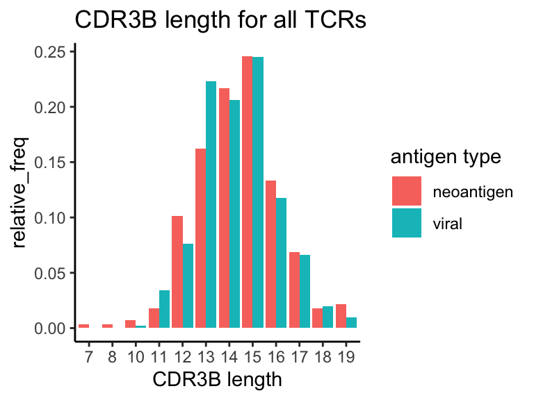

```r
df1 = df1[df1$`antigen type` != "self",]

df1$relative_freq = NA
for(a1 in unique(df1$`antigen type`)){
  wa = which(df1$`antigen type` == a1)
  df1$relative_freq[wa] = df1$freq[wa]/sum(df1$freq[wa])
}

ggplot(df1, aes(x = `CDR3B length`, y = relative_freq,
                fill=`antigen type`)) +
  geom_bar(stat = "identity", position = "dodge") +
  labs(title = "CDR3B length for all TCRs")
```

```r
t1 = table(df$CDR3B_len[w2use], df$antigen_type[w2use])
t1 = t1[,-2]

t1
```

```
##
##      neoantigen viral
##   7           1     0
##   8           1     0
##   10          2     1
##   11          5    14
##   12         28    31
##   13         45    91
##   14         60    84
##   15         68   100
##   16         37    48
##   17         19    27
##   18          5     8
##   19          6     4
```

```r
chisq.test(t1)
```

```
##
##  Pearson's Chi-squared test
##
## data:  t1
## X-squared = 11.685, df = 11, p-value = 0.3878
```

### Use of amino acids for all studies

```r
aas = strsplit(df$CDR3B, split="")
aas_by_antigen = tapply(aas, df$antigen_type, function(x){unlist(x)})

n_aa = lapply(aas_by_antigen, length)
n_aa
```

```
## $neoantigen
## [1] 3991
##
## $self
## [1] 218
##
## $viral
## [1] 8548
```

```r
df2 = data.frame(aa=c(aas_by_antigen$neoantigen, aas_by_antigen$viral),
                 antigen = rep(c("neoantigen", "viral"),
                               times=c(n_aa$neoantigen, n_aa$viral)))
dim(df2)
```

```
## [1] 12539     2
```

```r
df2[1:2,]
```

```
##   aa    antigen
## 1  C neoantigen
## 2  A neoantigen
```

```r
t1 = table(df2$aa, df2$antigen)
dim(t1)
```

```
## [1] 20  2
```

```r
t1
```

```
##
##     neoantigen viral
##   A        445   921
##   C        273   584
##   D         98   311
##   E        232   404
##   F        405   797
##   G        430   863
##   H         31    70
##   I         38    90
##   K         31    44
##   L        170   322
##   M          9    38
##   N        130   241
##   P        110   208
##   Q        231   572
##   R        144   271
##   S        609  1336
##   T        257   656
##   V         70   204
##   W         33    34
##   Y        244   581
```

```r
chisq.test(t1)
```

```
##
##  Pearson's Chi-squared test
##
## data:  t1
## X-squared = 60.271, df = 19, p-value = 3.505e-06
```

```r
t1 = t(t(t1)/colSums(t1))
t1 = round(data.matrix(t1),3)
dim(t1)
```

```
## [1] 20  2
```

```r
t1[1:2,]
```

```
##
##     neoantigen viral
##   A      0.112 0.108
##   C      0.068 0.068
```

```r
df1 = data.frame(aa = rownames(t1), neoantigen = t1[,1], viral = t1[,2])
dim(df1)
```

```
## [1] 20  3
```

```r
df1
```

```
##   aa neoantigen viral
## A  A      0.112 0.108
## C  C      0.068 0.068
## D  D      0.025 0.036
## E  E      0.058 0.047
## F  F      0.102 0.093
## G  G      0.108 0.101
## H  H      0.008 0.008
## I  I      0.010 0.011
## K  K      0.008 0.005
## L  L      0.043 0.038
## M  M      0.002 0.004
## N  N      0.033 0.028
## P  P      0.028 0.024
## Q  Q      0.058 0.067
## R  R      0.036 0.032
## S  S      0.153 0.156
## T  T      0.064 0.077
## V  V      0.018 0.024
## W  W      0.008 0.004
## Y  Y      0.061 0.068
```

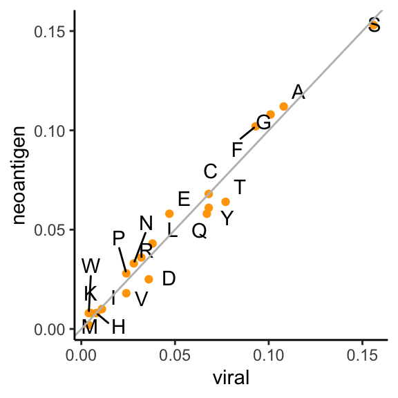

```r
ggplot(df1, aes(x=viral, y=neoantigen, label = aa)) +
  geom_point(color="orange") + geom_text_repel() +
  geom_abline(slope=1, intercept = 0, color="grey")
```

### Use of amino acids for all studies except Sudmeier et al. 2022

```r
table(df$study)
```

```
##
##   Caushi_2021   Hanada_2022   Lowery_2022 Sudmeier_2022   Veatch_2022
##           159            45            91           175           407
```

```r
df = df[df$study != "Sudmeier_2022",]
table(df$study)
```

```
##
## Caushi_2021 Hanada_2022 Lowery_2022 Veatch_2022
##         159          45          91         407
```

```r
aas = strsplit(df$CDR3B, split="")
aas_by_antigen = tapply(aas, df$antigen_type, function(x){unlist(x)})

n_aa = lapply(aas_by_antigen, length)
n_aa
```

```
## $neoantigen
## [1] 3991
##
## $self
## [1] 218
##
## $viral
## [1] 5843
```

```r
df2 = data.frame(aa=c(aas_by_antigen$neoantigen, aas_by_antigen$viral),
                 antigen = rep(c("neoantigen", "viral"),
                               times=c(n_aa$neoantigen, n_aa$viral)))
dim(df2)
```

```
## [1] 9834    2
```

```r
df2[1:2,]
```

```
##   aa    antigen
## 1  C neoantigen
## 2  A neoantigen
```

```r
t1 = table(df2$aa, df2$antigen)
dim(t1)
```

```
## [1] 20  2
```

```r
t1
```

```
##
##     neoantigen viral
##   A        445   605
##   C        273   409
##   D         98   172
##   E        232   292
##   F        405   603
##   G        430   590
##   H         31    69
##   I         38    76
##   K         31    44
##   L        170   220
##   M          9    21
##   N        130   199
##   P        110   166
##   Q        231   347
##   R        144   214
##   S        609   913
##   T        257   401
##   V         70   127
##   W         33    27
##   Y        244   347
```

```r
chisq.test(t1)
```

```
##
##  Pearson's Chi-squared test
##
## data:  t1
## X-squared = 25.34, df = 19, p-value = 0.1497
```

```r
t1 = t(t(t1)/colSums(t1))
t1 = round(data.matrix(t1),3)
dim(t1)
```

```
## [1] 20  2
```

```r
t1[1:2,]
```

```
##
##     neoantigen viral
##   A      0.112 0.104
##   C      0.068 0.070
```

```r
df1 = data.frame(aa = rownames(t1), neoantigen = t1[,1], viral = t1[,2])
dim(df1)
```

```
## [1] 20  3
```

```r
df1
```

```
##   aa neoantigen viral
## A  A      0.112 0.104
## C  C      0.068 0.070
## D  D      0.025 0.029
## E  E      0.058 0.050
## F  F      0.102 0.103
## G  G      0.108 0.101
## H  H      0.008 0.012
## I  I      0.010 0.013
## K  K      0.008 0.008
## L  L      0.043 0.038
## M  M      0.002 0.004
## N  N      0.033 0.034
## P  P      0.028 0.028
## Q  Q      0.058 0.059
## R  R      0.036 0.037
## S  S      0.153 0.156
## T  T      0.064 0.069
## V  V      0.018 0.022
## W  W      0.008 0.005
## Y  Y      0.061 0.059
```

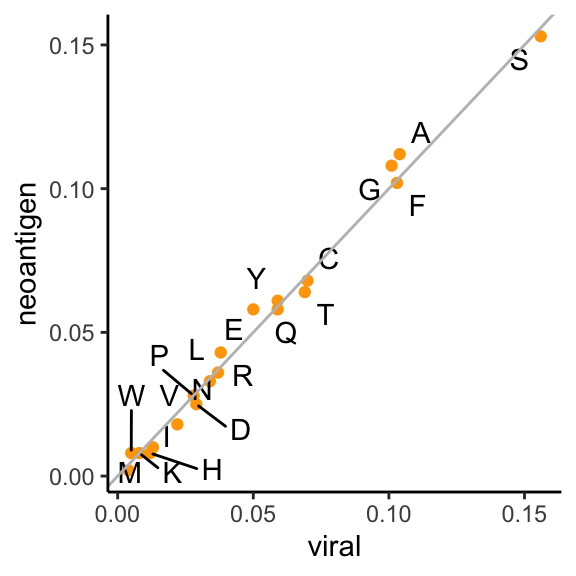

```r
ggplot(df1, aes(x=viral, y=neoantigen, label = aa)) +
  geom_point(color="orange") + geom_text_repel() +
  geom_abline(slope=1, intercept = 0, color="grey")
```

### Check those TCRs that target the same gene

```r
t1 = table(df$antigen)
table(t1)
```

```
## t1
##  1  2  3  4  5  6  7  8  9 10 11 13 20
## 65 23 10  5  3  2  3  3  2  1  1  1  1
```

```r
t1 = sort(t1, decreasing = TRUE)
t1[t1 >= 3]
```

```
##
##  NP_H1N1/H3N2 MP1_H1N1/H3N2         SNRPB          FLNA       NP_H3N2
##            20            13            11            10             9
##       PPP2R1A         ERAP1          KRAS          TP53       HTATSF1
##             9             8             8             8             7
##       NP_H1N1          TARS        DOPEY2          MUC6         BPNT1
##             7             7             6             6             5
##        CMKLR1          PGM2        COL5A1        FAM63A           FN1
##             5             5             4             4             4
##          POLE        POU3F3          BRAF         CNOT2          EGFR
##             4             4             3             3             3
##          GJB2         ITGB5          LCP1         MLLT4      MP1_H1N1
##             3             3             3             3             3
##        NUP214          TGFB
##             3             3
```

```r
cols = c("CDR3B", "antigen", "patient", "study")
df[which(df$antigen == "SNRPB"), cols]
```

```
##                  CDR3B antigen patient       study
## 256    CASNRGTGGVEKLFF   SNRPB    X198 Veatch_2022
## 257   CASGRGSTGGTGEQYF   SNRPB    X198 Veatch_2022
## 258  CASSFRQGGSSTDTQYF   SNRPB    X198 Veatch_2022
## 259  CASSVRQGASSTDTQYF   SNRPB    X198 Veatch_2022
## 260   CASSVGEGSSGNTIYF   SNRPB    X198 Veatch_2022
## 2611    CASSPRVDNEKLFF   SNRPB    X198 Veatch_2022
## 2621  CASAPRYLQVTHEQYF   SNRPB    X198 Veatch_2022
## 263               <NA>   SNRPB    X198 Veatch_2022
## 264    CASNRGAGGTDTQYF   SNRPB    X198 Veatch_2022
## 265  CASSVRQGPTSTDTQYF   SNRPB    X198 Veatch_2022
## 266  CASSVRQGAGSYNEQFF   SNRPB    X198 Veatch_2022
```

```r
df[which(df$antigen == "FLNA"), cols]
```

```
##                    CDR3B antigen  patient       study
## 1010     CASSDLAGLNYGYTF    FLNA MD01-004 Caushi_2021
## 182  CASSLAGLAGPLAKNIQYF    FLNA MD01-004 Caushi_2021
## 231       CASSLPGDPYEQYF    FLNA MD01-004 Caushi_2021
## 242      CASSLSGPVEDEQYF    FLNA MD01-004 Caushi_2021
## 291     CASSRGEGGSNQPQHF    FLNA MD01-004 Caushi_2021
## 322        CASSSGPSYEQYF    FLNA MD01-004 Caushi_2021
## 331        CASSSISTGELFF    FLNA MD01-004 Caushi_2021
## 342      CASSVDGGQSDEQYF    FLNA MD01-004 Caushi_2021
## 382          CASSYNNEQFF    FLNA MD01-004 Caushi_2021
## 442       CAWSEGRGNEKLFF    FLNA MD01-004 Caushi_2021
```

```r
df[which(df$antigen == "ERAP1"), cols]
```

```
##                   CDR3B antigen patient       study
## 279  CASSPSVGVSITSDTQYF   ERAP1    X198 Veatch_2022
## 280     CSASPRGASYNEQFF   ERAP1    X198 Veatch_2022
## 2811    CASSLGAGVRETQYF   ERAP1    X198 Veatch_2022
## 2821    CASSLGAGGPNEQFF   ERAP1    X198 Veatch_2022
## 283        CSARVLQETQYF   ERAP1    X198 Veatch_2022
## 284       CASSPFSSYEQYF   ERAP1    X198 Veatch_2022
## 285      CASSRQGGRYGYTF   ERAP1    X198 Veatch_2022
## 286       CSARRNLNQPQHF   ERAP1    X198 Veatch_2022
```

```r
df[which(df$antigen == "KRAS"), cols]
```

```
##                 CDR3B antigen patient       study
## 810     CASRIGNTGELFF    KRAS    4400 Lowery_2022
## 92       CASRNLGDTQYF    KRAS    4394 Lowery_2022
## 11      CASRQGNTGELFF    KRAS    4400 Lowery_2022
## 211    CASSGAEGAYEQYF    KRAS    4394 Lowery_2022
## 221    CASSGLTYTDTQYF    KRAS    4400 Lowery_2022
## 46     CASSPGTENSPLHF    KRAS    4400 Lowery_2022
## 51  CASSQDVTSEWVDTIYF    KRAS    4385 Lowery_2022
## 56      CASSQGNTGELFF    KRAS    4400 Lowery_2022
```

```r
df[which(df$antigen == "TP53"), cols]
```

```
##                 CDR3B antigen  patient       study
## 4        CASRAQGDGYTF    TP53     4324 Lowery_2022
## 241    CASSHAGENNEQYF    TP53     4324 Lowery_2022
## 27      CASSLAGPETQYF    TP53     4324 Lowery_2022
## 160    CASSLPGTPYEQYF    TP53 MD01-004 Caushi_2021
## 410  CAISEWRAGSTDTQYF    TP53 MD01-004 Caushi_2021
## 710    CASQSGILPWEQFF    TP53 MD01-004 Caushi_2021
## 1310 CASSEVQGASNEKLFF    TP53 MD01-004 Caushi_2021
## 421     CATTGGQNTEAFF    TP53 MD01-004 Caushi_2021
```

```r
df[which(df$antigen == "HTATSF1"), cols]
```

```
##                    CDR3B antigen patient       study
## 1921        CASSQGGYVLTF HTATSF1    X205 Veatch_2022
## 193         CATSRAQGEQYF HTATSF1    X205 Veatch_2022
## 194       CASRRTGGSGELFF HTATSF1    X205 Veatch_2022
## 195      CAISESTAAGVAQYF HTATSF1    X205 Veatch_2022
## 199  CASREDPGTGGGDSYGYTF HTATSF1    X205 Veatch_2022
## 2011      CASRRTGGNTEAFF HTATSF1    X205 Veatch_2022
## 2021     CASSARPEGTDTQYF HTATSF1    X205 Veatch_2022
```

```r
df[which(df$antigen == "BPNT1"), cols]
```

```
##               CDR3B antigen  patient       study
## 8   CASSALSGSINTQYF   BPNT1 Patient1 Hanada_2022
## 9   CASSPNSGSQNEQFF   BPNT1 Patient1 Hanada_2022
## 10    CSARDRTGYGYTF   BPNT1 Patient1 Hanada_2022
## 12 CASSDPGLAGHNEQFF   BPNT1 Patient1 Hanada_2022
## 13    CASSLGGRTEAFF   BPNT1 Patient1 Hanada_2022
```

```r
df[which(df$antigen == "POLE"), cols]
```

```
##                  CDR3B antigen  patient       study
## 1410   CASSFAGGGNQPQHF    POLE MD01-004 Caushi_2021
## 191      CASSLAPGNEQFF    POLE MD01-004 Caushi_2021
## 222   CASSLGDDSMNTEAFF    POLE MD01-004 Caushi_2021
## 371  CASSYLVGAGSNYGYTF    POLE MD01-004 Caushi_2021
```

```r
df[which(df$antigen == "BRAF"), cols]
```

```
##                CDR3B antigen patient       study
## 514   CASNEGNSGNTIYF    BRAF    X197 Veatch_2022
## 615     CASGARQIPYTF    BRAF    X197 Veatch_2022
## 714 CASSLSAAGGGYGYTF    BRAF    X197 Veatch_2022
```

```r
df[which(df$antigen == "EGFR"), cols]
```

```
##              CDR3B antigen  patient       study
## 21   CASSSGQFYGYTF    EGFR Patient1 Hanada_2022
## 22 CASSLAGSGANVLTF    EGFR Patient1 Hanada_2022
## 24  CAYSPGLASDTQYF    EGFR Patient1 Hanada_2022
```

```r
df[which(df$antigen == "TGFB"), cols]
```

```
##               CDR3B antigen patient       study
## 2521 CASSYSTGESEAFF    TGFB    X198 Veatch_2022
## 2531  CSAEGGPTDTQYF    TGFB    X198 Veatch_2022
## 254  CASSYEGLAGELFF    TGFB    X198 Veatch_2022
```

# Session information

```r
gc()
```

```
##           used  (Mb) gc trigger  (Mb) limit (Mb) max used  (Mb)
## Ncells 4438807 237.1    7302484 390.0         NA  7302484 390.0
## Vcells 7809355  59.6   14786712 112.9      65536 10151851  77.5
```